# CpGoe Multiple species

Guillem Ylla

11/26/2019

.

## Load CpGoe values

CpGoe calculated in: Count_CpGoe.ipynb

```r
CpGoe_insects <- read.delim("CpGoe_outputs/All_insects_CpGpe")
CpGoe_insects <- CpGoe_insects[!is.na(CpGoe_insects$CpGoe), ]
```

## Overview CpGoe 16 Insects

Plot the CpG distribution for all 16 insects:

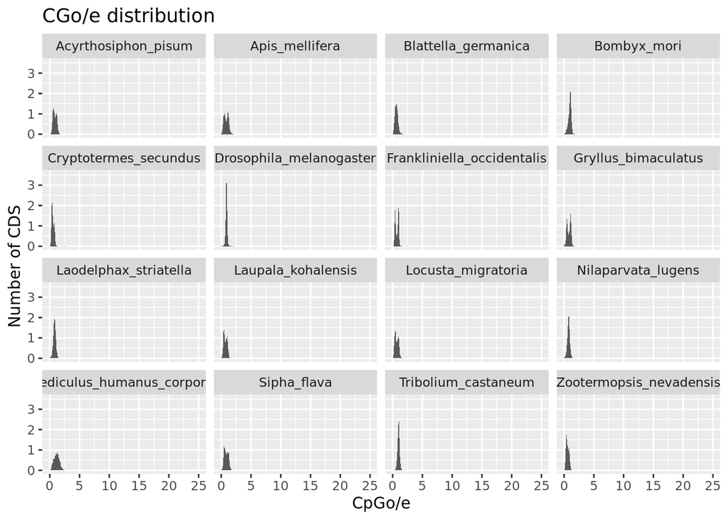

```r
CGoe_plot1 <- ggplot(CpGoe_insects, aes(x = CpGoe, y = ..density..)) +
    facet_wrap(~Spp) + geom_histogram(bins = 1000) + scale_x_continuous(name = "CpGo/e") +
    ggtitle("CGo/e distribution") + ylab("Number of CDS")
CGoe_plot1
```

Same, but removing genes CpGoe>2.

```r
dim(CpGoe_insects[CpGoe_insects$CpGoe > 2, ])
```

```
## [1] 448   8
```

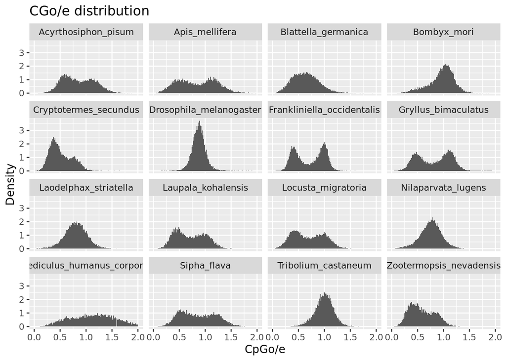

```r
CpGoe_insects_nolarger2 <- CpGoe_insects[CpGoe_insects$CpGoe <
    2, ]

CpGoe_insects_b02 <- CpGoe_insects[CpGoe_insects$CpGoe < 2 &
    CpGoe_insects$CpGoe > 0, ]


CGoe_plot2 <- ggplot(CpGoe_insects_b02, aes(x = CpGoe, y = ..density..)) +
    facet_wrap(~Spp) + geom_histogram(bins = 150) + scale_x_continuous(name = "CpGo/e") +
    ggtitle("CGo/e distribution") + ylab("Density")
CGoe_plot2
```

```r
CGoe_plotMiniatures<-ggplot(CpGoe_insects_b02, aes(x=CpGoe,  y = ..density.. )) +
   facet_wrap(~Spp)+
   geom_histogram(bins=150, colour="black")+
   scale_x_continuous(name = "CpGo/e") +
  ggtitle("CGo/e distribution")  +ylab("Density")+
theme(
    #plot.background = element_rect(fill = "transparent", color = NA), # bg of the plot
    panel.grid.major = element_blank(), # get rid of major grid
    panel.grid.minor = element_blank(), # get rid of minor grid
    panel.background = element_rect(fill = "transparent",colour = NA),
    plot.background = element_rect(fill = "transparent",colour = NA),
    axis.text.x=element_blank(),
    axis.text.y=element_blank(),
    axis.ticks.x=element_blank(),
   axis.ticks.y=element_blank(),
    legend.background = element_rect(fill = "transparent"), # get rid of legend bg
    legend.box.background = element_rect(fill = "transparent") # get rid of legend panel bg
  )
```

## CpGoe bimodal model 16 insects (Fig 2A)

Lets try to fit all of them in a bimodal distribution with a gaussian Mixture model.

```r
for (species in unique(CpGoe_insects$Spp)) {
    print(species)
    # only cpg values >0 & <2
    CpGoe_Spp <- CpGoe_insects_b02[CpGoe_insects_b02$Spp == species,
        ]
    # CpGoe_Spp<-CpGoe_insects[CpGoe_insects$Spp==species,]
    CpGoe_toplot = CpGoe_Spp$CpGoe
    CpGoe_toplot <- CpGoe_toplot[!is.na(CpGoe_toplot)]
    mixmdl = normalmixEM(CpGoe_toplot, maxit = 20000)

    # Standard Error function from mixtools bootsratping 100
    se <- boot.se(mixmdl, B = 100)
    # Intervals
    CI_1_right = mixmdl$mu[1] + (se$mu.se[1] * 2.8)
    CI_1_left = mixmdl$mu[1] - (se$mu.se[1] * 2.8)

    CI_2_right = mixmdl$mu[2] + (se$mu.se[2] * 2.8)
    CI_2_left = mixmdl$mu[2] - (se$mu.se[2] * 2.8)


    ## function for ggplots:
    plot_mix_comps <- function(x, mu, sigma, lam) {
        lam * dnorm(x, mu, sigma)
    }


    Biomdal_dist <- data.frame(x = mixmdl$x) %>% ggplot() + geom_histogram(aes(x,
        ..density..), colour = "black", alpha = 0.8, bins = 120) +
        stat_function(geom = "line", fun = plot_mix_comps, args = list(mixmdl$mu[1],
            mixmdl$sigma[1], lam = mixmdl$lambda[1]), colour = "#E69F00",
            lwd = 1) + stat_function(geom = "line", fun = plot_mix_comps,
        args = list(mixmdl$mu[2], mixmdl$sigma[2], lam = mixmdl$lambda[2]),
        colour = "#56B4E9", lwd = 1) + geom_vline(xintercept = mixmdl$mu[1],
        col = "#E69F00", size = 0.8) + annotate("text", label = round(mixmdl$mu[1],
        3), y = 1.6, x = mixmdl$mu[1] + 0.01, col = "#E69F00",
        size = 4) + annotate("rect", xmin = CI_1_left, xmax = CI_1_right,
        ymin = 0, ymax = Inf, alpha = 0.2, fill = "red") + geom_vline(xintercept = mixmdl$mu[2],
        col = "#56B4E9", size = 0.8) + annotate("rect", xmin = CI_2_left,
        xmax = CI_2_right, ymin = 0, ymax = Inf, alpha = 0.2,
        fill = "red") + annotate("text", label = round(mixmdl$mu[2],
        3), y = 1.2, x = mixmdl$mu[2] + 0.01, col = "#56B4E9",
        size = 4) + annotate("text", label = round(round(mixmdl$lambda[1],
        2), 3), y = 1.6, x = mixmdl$mu[1] - 0.3, col = "black",
        size = 4) + annotate("text", label = round(round(mixmdl$lambda[2],
        2), 3), y = 1.2, x = mixmdl$mu[2] + 0.3, col = "black",
        size = 4) + ylab("Density") + xlab("CpGo/e") + ggtitle(species)


    # red line spearateing
    data <- ggplot_build(Biomdal_dist)$data[[1]]
    data_int <- data[data$x > mixmdl$mu[1] & data$x < mixmdl$mu[2],
        ]
    cpg_threshold <- data_int[data_int$y == min(data_int$y),
        ]$x
    Biomdal_dist <- Biomdal_dist + geom_vline(xintercept = cpg_threshold,
        col = "red", size = 0.5) + annotate("text", label = round(cpg_threshold,
        3), y = 1.3, x = cpg_threshold + 0.01, col = "red", size = 4)


    # ggsave(paste0('plots/',paste0(species, '_CpGplot.png')),
    # Biomdal_dist, width = 9, height =5, units ='in',dpi = 300,)

}
```

The Gussian Mixture model, fits 2 gaussian ditributions to the CpGoe of each insect.

I get the mean of each curve (vertical bars) an calculate the standard error (SE) of each mean with 100 bootstraps The SE is used to calculate the 99% confidence interval around the mean (red shade).

The red line represents the intersection between the 2 curves, and it is used as threshold between genes with **Low and High CpGoe**.

```r
plots <- list.files("CpGoe/plots/")

for (i in plots) {
    if (grepl("_CpGplot.png", i)) {
        filename <- file.path("CpGoe/plots", i)
        cat("![text](", filename, ")\n")
    }
}
```

## Gryllus bimaculatus CpGoe distribution

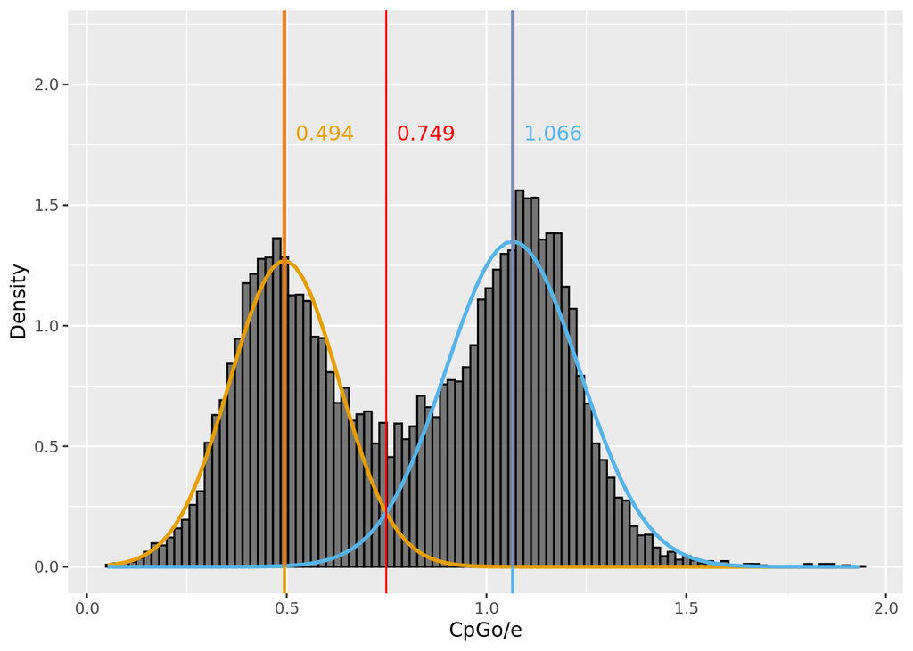

```r
Gbi_CpG <- CpGoe_insects_b02[CpGoe_insects_b02$Spp == "Gryllus_bimaculatus",
    ]

CpGoe_toplotGbi = Gbi_CpG$CpGoe
CpGoe_toplotGbi <- CpGoe_toplotGbi[!is.na(CpGoe_toplotGbi)]
mixmdlGbi = normalmixEM(CpGoe_toplotGbi, maxit = 20000)


## Calculating SE using mixtools bootystrap function
se <- boot.se(mixmdlGbi, B = 100)
# confidence intervals
CI_1_right = mixmdlGbi$mu[1] + (se$mu.se[1] * 2.8)
CI_1_left = mixmdlGbi$mu[1] - (se$mu.se[1] * 2.8)

CI_2_right = mixmdlGbi$mu[2] + (se$mu.se[2] * 2.8)
CI_2_left = mixmdlGbi$mu[2] - (se$mu.se[2] * 2.8)


## In ggplots:
plot_mix_comps <- function(x, mu, sigma, lam) {
    lam * dnorm(x, mu, sigma)
}


Bimodal_Gbi <- data.frame(x = mixmdlGbi$x) %>% ggplot() + geom_histogram(aes(x,
    ..density..), colour = "black", alpha = 0.8, bins = 100) +
    stat_function(geom = "line", fun = plot_mix_comps, args = list(mixmdlGbi$mu[1],
        mixmdlGbi$sigma[1], lam = mixmdlGbi$lambda[1]), colour = "#E69F00",
        lwd = 1) + stat_function(geom = "line", fun = plot_mix_comps,
    args = list(mixmdlGbi$mu[2], mixmdlGbi$sigma[2], lam = mixmdlGbi$lambda[2]),
    colour = "#56B4E9", lwd = 1) + geom_vline(xintercept = mixmdlGbi$mu[1],
    col = "#E69F00", size = 0.8) + annotate("rect", xmin = CI_1_left,
    xmax = CI_1_right, ymin = 0, ymax = Inf, alpha = 0.2, fill = "red") +
    annotate("text", label = round(mixmdlGbi$mu[1], 3), y = 1.8,
        x = mixmdlGbi$mu[1] + 0.1, col = "#E69F00", size = 4) +
    geom_vline(xintercept = mixmdlGbi$mu[2], col = "#56B4E9",
        size = 0.8) + annotate("rect", xmin = CI_2_left, xmax = CI_2_right,
    ymin = 0, ymax = Inf, alpha = 0.2, fill = "red") + annotate("text",
    label = round(mixmdlGbi$mu[2], 3), y = 1.8, x = mixmdlGbi$mu[2] +
        0.1, col = "#56B4E9", size = 4) + ylab("Density") + xlab("CpGo/e") +
    ylim(0, 2.2)


### I separate the 2 distributions by the lowest density
### between means
curve1 <- function(x) mixmdlGbi$lambda[1] * dnorm(x, mixmdlGbi$mu[1],
    mixmdlGbi$sigma[1])
curve2 <- function(x) mixmdlGbi$lambda[2] * dnorm(x, mixmdlGbi$mu[2],
    mixmdlGbi$sigma[2])

curveintersectGbi <- curve_intersect(curve1, curve2, empirical = FALSE,
    domain = c(0, 5))

Gbi_cpg_threshold = curveintersectGbi$x


Bimodal_Gbi <- Bimodal_Gbi + geom_vline(xintercept = Gbi_cpg_threshold,
    col = "red", size = 0.5) + annotate("text", label = round(Gbi_cpg_threshold,
    3), y = 1.8, x = Gbi_cpg_threshold + 0.1, col = "red", size = 4)

Bimodal_Gbi
```

## Laupala kohalensis CpGoe distribution

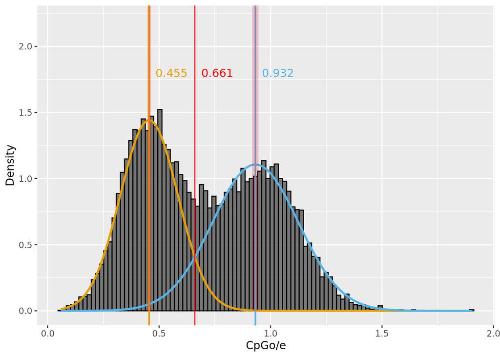

```r
Lko_CpG <- CpGoe_insects_b02[CpGoe_insects_b02$Spp == "Laupala_kohalensis",
    ]

CpGoe_toplotLko = Lko_CpG$CpGoe
CpGoe_toplotLko <- CpGoe_toplotLko[!is.na(CpGoe_toplotLko)]
mixmdlLko = normalmixEM(CpGoe_toplotLko, maxit = 20000)

## Calculating SE using mixtools bootystrap function
se <- boot.se(mixmdlLko, B = 100)
# confidence intervals
CI_1_right = mixmdlLko$mu[1] + (se$mu.se[1] * 2.8)
CI_1_left = mixmdlLko$mu[1] - (se$mu.se[1] * 2.8)

CI_2_right = mixmdlLko$mu[2] + (se$mu.se[2] * 2.8)
CI_2_left = mixmdlLko$mu[2] - (se$mu.se[2] * 2.8)

## In ggplots:
plot_mix_comps <- function(x, mu, sigma, lam) {
    lam * dnorm(x, mu, sigma)
}


Bimodal_Lko <- data.frame(x = mixmdlLko$x) %>% ggplot() + geom_histogram(aes(x,
    ..density..), colour = "black", alpha = 0.8, bins = 100) +
    stat_function(geom = "line", fun = plot_mix_comps, args = list(mixmdlLko$mu[1],
        mixmdlLko$sigma[1], lam = mixmdlLko$lambda[1]), colour = "#E69F00",
        lwd = 1) + stat_function(geom = "line", fun = plot_mix_comps,
    args = list(mixmdlLko$mu[2], mixmdlLko$sigma[2], lam = mixmdlLko$lambda[2]),
    colour = "#56B4E9", lwd = 1) + geom_vline(xintercept = mixmdlLko$mu[1],
    col = "#E69F00", size = 0.8) + annotate("rect", xmin = CI_1_left,
    xmax = CI_1_right, ymin = 0, ymax = Inf, alpha = 0.2, fill = "red") +
    annotate("text", label = round(mixmdlLko$mu[1], 3), y = 1.8,
        x = mixmdlLko$mu[1] + 0.1, col = "#E69F00", size = 4) +
    geom_vline(xintercept = mixmdlLko$mu[2], col = "#56B4E9",
        size = 0.8) + annotate("rect", xmin = CI_2_left, xmax = CI_2_right,
    ymin = 0, ymax = Inf, alpha = 0.2, fill = "red") + annotate("text",
    label = round(mixmdlLko$mu[2], 3), y = 1.8, x = mixmdlLko$mu[2] +
        0.1, col = "#56B4E9", size = 4) + # annotate('text',label=paste0('LogLik=',round(mixmdlLko$loglik,
# 1)),y= 1.5, x=1.5, col='black',size=4)+
ylab("Density") + xlab("CpGo/e") + ylim(0, 2.2)


### I separate the 2 distributions by the lowest density
### between means
curve1 <- function(x) mixmdlLko$lambda[1] * dnorm(x, mixmdlLko$mu[1],
    mixmdlLko$sigma[1])
curve2 <- function(x) mixmdlLko$lambda[2] * dnorm(x, mixmdlLko$mu[2],
    mixmdlLko$sigma[2])

curveintersectLko <- curve_intersect(curve1, curve2, empirical = FALSE,
    domain = c(0, 5))

Lko_cpg_threshold = curveintersectLko$x


Bimodal_Lko <- Bimodal_Lko + geom_vline(xintercept = Lko_cpg_threshold,
    col = "red", size = 0.5) + annotate("text", label = round(Lko_cpg_threshold,
    3), y = 1.8, x = Lko_cpg_threshold + 0.1, col = "red", size = 4)

Bimodal_Lko
```

## Apis mellifera CpGoe distribution

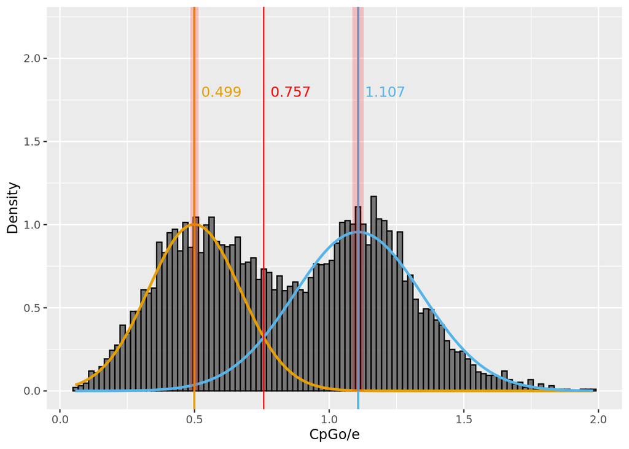

```r
Ame_CpG <- CpGoe_insects_b02[CpGoe_insects_b02$Spp == "Apis_mellifera",
    ]

CpGoe_toplotAme = Ame_CpG$CpGoe
CpGoe_toplotAme <- CpGoe_toplotAme[!is.na(CpGoe_toplotAme)]
mixmdlAme = normalmixEM(CpGoe_toplotAme, maxit = 20000)

## Calculating SE using mixtools bootystrap function
se <- boot.se(mixmdlAme, B = 100)
# confidence intervals
CI_1_right = mixmdlAme$mu[1] + (se$mu.se[1] * 2.8)
CI_1_left = mixmdlAme$mu[1] - (se$mu.se[1] * 2.8)

CI_2_right = mixmdlAme$mu[2] + (se$mu.se[2] * 2.8)
CI_2_left = mixmdlAme$mu[2] - (se$mu.se[2] * 2.8)

## In ggplots:
plot_mix_comps <- function(x, mu, sigma, lam) {
    lam * dnorm(x, mu, sigma)
}


Bimodal_Ame <- data.frame(x = mixmdlAme$x) %>% ggplot() + geom_histogram(aes(x,
    ..density..), colour = "black", alpha = 0.8, bins = 100) +
    stat_function(geom = "line", fun = plot_mix_comps, args = list(mixmdlAme$mu[1],
        mixmdlAme$sigma[1], lam = mixmdlAme$lambda[1]), colour = "#E69F00",
        lwd = 1) + stat_function(geom = "line", fun = plot_mix_comps,
    args = list(mixmdlAme$mu[2], mixmdlAme$sigma[2], lam = mixmdlAme$lambda[2]),
    colour = "#56B4E9", lwd = 1) + geom_vline(xintercept = mixmdlAme$mu[1],
    col = "#E69F00", size = 0.8) + annotate("rect", xmin = CI_1_left,
    xmax = CI_1_right, ymin = 0, ymax = Inf, alpha = 0.2, fill = "red") +
    annotate("text", label = round(mixmdlAme$mu[1], 3), y = 1.8,
        x = mixmdlAme$mu[1] + 0.1, col = "#E69F00", size = 4) +
    geom_vline(xintercept = mixmdlAme$mu[2], col = "#56B4E9",
        size = 0.8) + annotate("rect", xmin = CI_2_left, xmax = CI_2_right,
    ymin = 0, ymax = Inf, alpha = 0.2, fill = "red") + annotate("text",
    label = round(mixmdlAme$mu[2], 3), y = 1.8, x = mixmdlAme$mu[2] +
        0.1, col = "#56B4E9", size = 4) + ylab("Density") + xlab("CpGo/e") +
    ylim(0, 2.2)


### I separate the 2 distributions by the lowest density
### between means

curve1 <- function(x) mixmdlAme$lambda[1] * dnorm(x, mixmdlAme$mu[1],
    mixmdlAme$sigma[1])
curve2 <- function(x) mixmdlAme$lambda[2] * dnorm(x, mixmdlAme$mu[2],
    mixmdlAme$sigma[2])

curveintersectAme <- curve_intersect(curve1, curve2, empirical = FALSE,
    domain = c(0, 5))

Ame_cpg_threshold = curveintersectAme$x
Bimodal_Ame <- Bimodal_Ame + geom_vline(xintercept = Ame_cpg_threshold,
    col = "red", size = 0.5) + annotate("text", label = round(Ame_cpg_threshold,
    3), y = 1.8, x = Ame_cpg_threshold + 0.1, col = "red", size = 4)

Bimodal_Ame
```

## Frankliniella occidentalis

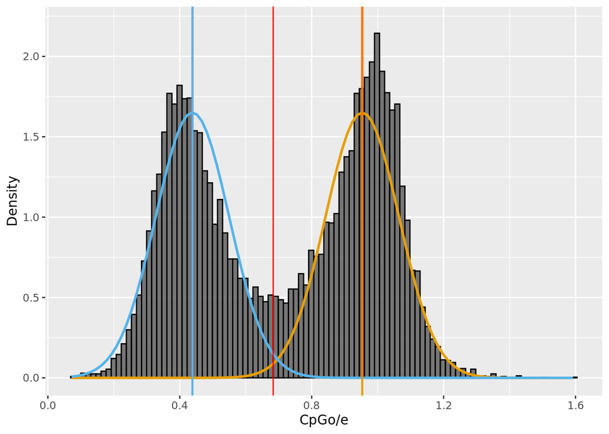

```r
Foc_CpG <- CpGoe_insects_b02[CpGoe_insects_b02$Spp == "Frankliniella_occidentalis",
    ]

CpGoe_toplotFoc = Foc_CpG$CpGoe
CpGoe_toplotFoc <- CpGoe_toplotFoc[!is.na(CpGoe_toplotFoc)]
mixmdlFoc = normalmixEM(CpGoe_toplotFoc, maxit = 20000)


## Calculating SE using mixtools bootystrap function
se <- boot.se(mixmdlFoc, B = 100)
# confidence intervals
CI_1_right = mixmdlFoc$mu[1] + (se$mu.se[1] * 2.8)
CI_1_left = mixmdlFoc$mu[1] - (se$mu.se[1] * 2.8)

CI_2_right = mixmdlFoc$mu[2] + (se$mu.se[2] * 2.8)
CI_2_left = mixmdlFoc$mu[2] - (se$mu.se[2] * 2.8)



## In ggplots:
plot_mix_comps <- function(x, mu, sigma, lam) {
    lam * dnorm(x, mu, sigma)
}

Bimodal_Foc <- data.frame(x = mixmdlFoc$x) %>% ggplot() + geom_histogram(aes(x,
    ..density..), colour = "black", alpha = 0.8, bins = 100) +
    stat_function(geom = "line", fun = plot_mix_comps, args = list(mixmdlFoc$mu[2],
        mixmdlFoc$sigma[1], lam = mixmdlFoc$lambda[1]), colour = "#E69F00",
        lwd = 1) + stat_function(geom = "line", fun = plot_mix_comps,
    args = list(mixmdlFoc$mu[1], mixmdlFoc$sigma[1], lam = mixmdlFoc$lambda[1]),
    colour = "#56B4E9", lwd = 1) + geom_vline(xintercept = mixmdlFoc$mu[2],
    col = "#E69F00", size = 0.8) + annotate("rect", xmin = CI_1_left,
    xmax = CI_1_right, ymin = 0, ymax = Inf, alpha = 0.2, fill = "red") +
    geom_vline(xintercept = mixmdlFoc$mu[1], col = "#56B4E9",
        size = 0.8) + annotate("rect", xmin = CI_2_left, xmax = CI_2_right,
    ymin = 0, ymax = Inf, alpha = 0.2, fill = "red") + ylab("Density") +
    xlab("CpGo/e") + ylim(0, 2.2)



curve1 <- function(x) mixmdlFoc$lambda[1] * dnorm(x, mixmdlFoc$mu[1],
    mixmdlFoc$sigma[1])
curve2 <- function(x) mixmdlFoc$lambda[2] * dnorm(x, mixmdlFoc$mu[2],
    mixmdlFoc$sigma[2])

curveintersectFoc <- curve_intersect(curve1, curve2, empirical = FALSE,
    domain = c(0, 5))

Foc_cpg_threshold = curveintersectFoc$x


Bimodal_Foc <- Bimodal_Foc + geom_vline(xintercept = Foc_cpg_threshold,
    col = "red", size = 0.5)
annotate("text", label = round(Foc_cpg_threshold, 3), y = 1.8,
    x = Foc_cpg_threshold + 0.1, col = "red", size = 4)

Bimodal_Foc
```

## CpGoe vs Orthology

- Assign genes no High or Low CpGoe peak based on the threshols stablished before

```r
Gbi_CpG <- CpGoe_insects_b02[CpGoe_insects_b02$Spp == "Gryllus_bimaculatus",
    ]

Gbi_CpG$CpGoe_level <- "NA"
Gbi_CpG$CpGoe_level[Gbi_CpG$CpGoe > Gbi_cpg_threshold] <- "High"
Gbi_CpG$CpGoe_level[Gbi_CpG$CpGoe <= Gbi_cpg_threshold] <- "Low"

Gbi_CpG$Gene <- sapply(strsplit(as.character(Gbi_CpG$ID), "-"),
    `[`, 1)

Lko_CpG <- CpGoe_insects_b02[CpGoe_insects_b02$Spp == "Laupala_kohalensis",
    ]

Lko_CpG$CpGoe_level <- "NA"
Lko_CpG$CpGoe_level[Lko_CpG$CpGoe > Lko_cpg_threshold] <- "High"
Lko_CpG$CpGoe_level[Lko_CpG$CpGoe <= Lko_cpg_threshold] <- "Low"
Lko_CpG$Gene <- sapply(strsplit(as.character(Lko_CpG$ID), "-"),
    `[`, 1)
```

```r
Ame_CpG <- CpGoe_insects[CpGoe_insects$Spp == "Apis_mellifera",
    ]

Ame_CpG$CpGoe_level <- "NA"
Ame_CpG$CpGoe_level[Ame_CpG$CpGoe > Ame_cpg_threshold] <- "High"
Ame_CpG$CpGoe_level[Ame_CpG$CpGoe <= Ame_cpg_threshold] <- "Low"

Ame_CpG$Gene <- sapply(strsplit(as.character(Ame_CpG$ID), "-"),
    `[`, 2)
```

```r
Foc_CpG <- CpGoe_insects[CpGoe_insects$Spp == "Frankliniella_occidentalis",
    ]

Foc_CpG$CpGoe_level <- "NA"
Foc_CpG$CpGoe_level[Foc_CpG$CpGoe > Foc_cpg_threshold] <- "High"
Foc_CpG$CpGoe_level[Foc_CpG$CpGoe <= Foc_cpg_threshold] <- "Low"

Foc_CpG$Gene <- Foc_CpG$ID
```

```r
FocAmeGbiLko_insects_CpGeo <- rbind(Foc_CpG, Ame_CpG, Lko_CpG,
    Gbi_CpG)

## reorder: 1st low, then high
FocAmeGbiLko_insects_CpGeo$CpGoe_level <- factor(FocAmeGbiLko_insects_CpGeo$CpGoe_level,
    levels = c("Low", "High"))
```

- Get Orthology info

```python
##### I need to transform OG table to to 2 column OG-gene
Gene_OG_dict = {}
with open("CpGoe_outputs/Orthogroups.txt") as f:
    for line in f:
       line=line.rstrip()
       (OG, genes) = line.split(":")
       geneeList=genes.split()
       Gene_OG_dict[OG] = geneeList

fout= open("CpGoe_outputs/Orthogroups_list_OG_gene.txt","w+")
for key in Gene_OG_dict:
  for value in Gene_OG_dict[key]:
    fout.write(key+"\t"+value+"\n")

fout.close()
```

- Load OGs

```r
OG_Gene <- read.delim("CpGoe_outputs/Orthogroups_list_OG_gene.txt",
    header = FALSE, stringsAsFactors = FALSE)
colnames(OG_Gene) <- c("OG", "Transc")
```

- Assign Genes to their corresponding Orthogroup

```r
# rename GBI transcripts
OG_Gene$Transcript <- OG_Gene$Transc
OG_Gene[OG_Gene$Transcript %like% "Gbi", ]$Transcript <- sapply(strsplit(as.character(OG_Gene[OG_Gene$Transc %like%
    "Gbi", "Transcript"]), "Gbi_"), `[`, 2)
head(OG_Gene)
OG_Gene[OG_Gene$Transc %like% "GBI", ]
# rename Lko transcripts
OG_Gene[OG_Gene$Transcript %like% "Lko", ]$Transcript <- paste0("Lko_",
    sapply(strsplit(as.character(OG_Gene[OG_Gene$Transc %like%
        "Lko", "Transcript"]), "Lko_Lko_"), `[`, 2))
head(OG_Gene)
OG_Gene[OG_Gene$Transc %like% "Lko", ]

# rename Foc transcripts
OG_Gene[OG_Gene$Transcript %like% "Foc", ]$Transcript <- sapply(strsplit(as.character(OG_Gene[OG_Gene$Transc %like%
    "Foc", "Transcript"]), "Foc_"), `[`, 2)
head(OG_Gene)
OG_Gene[OG_Gene$Transc %like% "Foc", ]

# rename Ame transcipts
Ame_cds_gene_dic <- read.delim("Ame_Gene_CDS_dict.txt", header = FALSE,
    sep = " ")
head(Ame_cds_gene_dic)
Ame_cds_gene_dic$LOC <- paste0("Ame_", Ame_cds_gene_dic$V1)

FocAmeGbiLko_insects_CpGeo_amerenames <- merge(FocAmeGbiLko_insects_CpGeo,
    Ame_cds_gene_dic, by.x = "Gene", by.y = "V2")
head(FocAmeGbiLko_insects_CpGeo_amerenames)

OG_Gene[OG_Gene$Transc %like% "Ame", ]

Ame_DF <- FocAmeGbiLko_insects_CpGeo_amerenames[, c("Spp", "Abb",
    "LOC", "Len", "Gfreq", "Cfreq", "CGfreq", "CpGoe", "CpGoe_level",
    "ID")]
colnames(Ame_DF) <- colnames(FocAmeGbiLko_insects_CpGeo)
# remove ame
dim(FocAmeGbiLko_insects_CpGeo)
FocAmeGbiLko_insects_CpGeo_v2 <- FocAmeGbiLko_insects_CpGeo[!FocAmeGbiLko_insects_CpGeo$Abb ==
    "Ame", ]
dim(FocAmeGbiLko_insects_CpGeo_v2)
# Add Ame with new names
FocAmeGbiLko_insects_CpGeo_v3 <- rbind(FocAmeGbiLko_insects_CpGeo_v2,
    Ame_DF)
dim(FocAmeGbiLko_insects_CpGeo_v3)


AmeGbiLko_CpGeo_OG <- merge(FocAmeGbiLko_insects_CpGeo_v3, OG_Gene,
    by.x = "ID", by.y = "Transcript")

table(AmeGbiLko_CpGeo_OG$Spp)
dim(Gbi_CpG)  #all matched woth gene and OG
dim(Lko_CpG)  #all matched woth gene and OG
dim(Ame_CpG)  # I lost just 1 gene
dim(Foc_CpG)  #all matched woth gene and OG
```

### CpGoe and proportion of species-specific genes (Fig 2C)

- The Orthogroups.txt generated by OrthoFinder2 assigns ALL genes to OG. Genes that have no ortholog or paralog have their own OG.

```r
NGenesInOG <- table(OG_Gene$OG)

Genes_per_OG_FocAmeGbiLko_CpGeo_OG <- AmeGbiLko_CpGeo_OG

Genes_per_OG_FocAmeGbiLko_CpGeo_OG$GenesinOG <- NGenesInOG[Genes_per_OG_FocAmeGbiLko_CpGeo_OG$OG]
```

- Get real species-specific genes

```r
OG_Gene_copy <- OG_Gene

OG_Gene_copy$Spp <- sapply(strsplit(OG_Gene_copy$Transc, "_"),
    `[`, 1)
table(OG_Gene_copy$Spp)
```

```
##
##   Ame   Api   Bge   Bmo   Cse   Dme   Foc   Gbi   Lko   Lmi   Lst   Nlu   Phu
##  9934 18274 25509 13800 12810 13933 15678 17871 12767 17586 17512 19819 10773
##   Sfl   Tca   Zne
## 13575 12873 12381
```

```r
Spp_Specific_genes <- OG_Gene_copy %>% group_by(Spp, OG) %>%
    tally(name = "Paralogs") %>% group_by(OG) %>% mutate(Orthologs = n()) %>%
    filter(Orthologs == 1)

dim(Spp_Specific_genes)
```

```
## [1] 45360     4
```

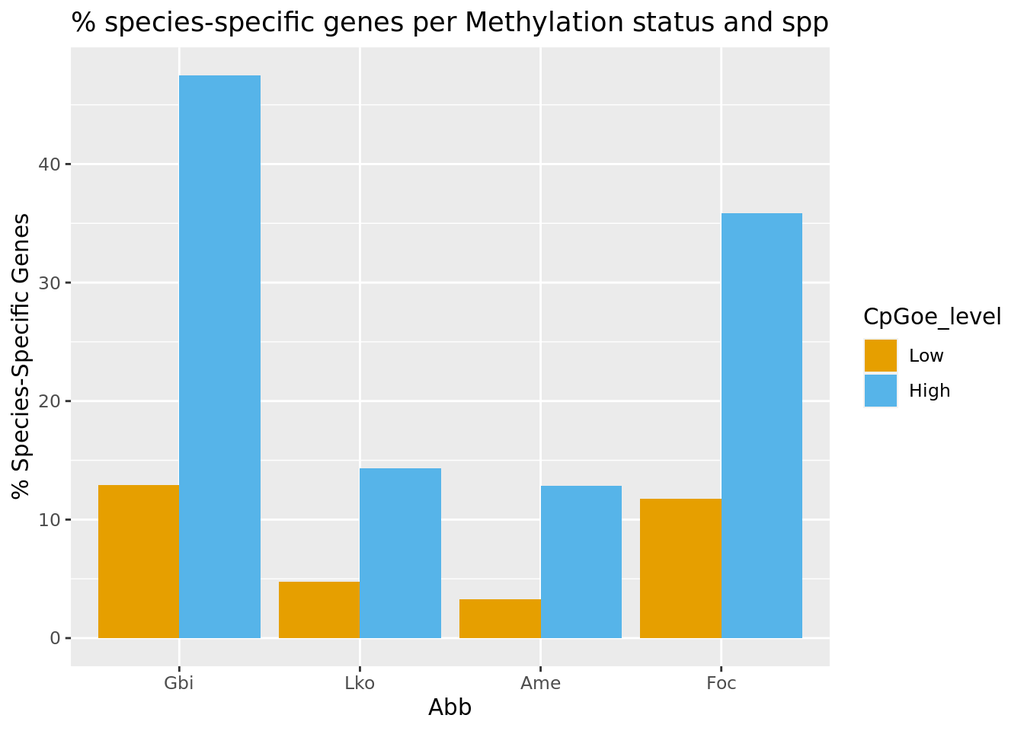

```r
SpSpecGenes_Met<-Genes_per_OG_FocAmeGbiLko_CpGeo_OG %>%
  mutate(CpGoe_level=fct_relevel(CpGoe_level, c("Low","High"))) %>%
   mutate(Abb=fct_relevel(Abb, c("Gbi","Lko","Ame","Foc"))) %>%
  mutate(SpeciSpecific=ifelse(OG%in%Spp_Specific_genes$OG, "yes","no")) %>% # get species-specific
  group_by(Abb,CpGoe_level, SpeciSpecific ) %>%
  tally(name="Num.Genes") %>%
  mutate(freq_Speciespecific = Num.Genes / sum(Num.Genes)*100) %>%
  filter(SpeciSpecific=="yes") %>%

  ggplot(., aes(x=Abb, y=freq_Speciespecific, fill=CpGoe_level)) +
    geom_bar(stat="identity", position = "dodge")+
    ylab("% Species-Specific Genes")+#scale_fill_grey(start = 0.1,end = 0.8,)+
   scale_fill_manual(breaks = c("Low", "High"),values=c("#E69F00","#56B4E9"))+
    ggtitle("% species-specific genes per Methylation status and spp")

SpSpecGenes_Met
```

```r
Genes_per_OG_FocAmeGbiLko_CpGeo_OG %>%
  mutate(CpGoe_level=fct_relevel(CpGoe_level, c("Low","High"))) %>%
   mutate(Abb=fct_relevel(Abb, c("Gbi","Lko","Ame","Foc"))) %>%
  mutate(SpeciSpecific=ifelse(OG%in%Spp_Specific_genes$OG, "yes","no")) %>% # get species-specific
  group_by(Abb,CpGoe_level, SpeciSpecific ) %>%
  tally(name="Num.Genes") %>%
  mutate(freq_Speciespecific = Num.Genes / sum(Num.Genes)*100) %>%
  filter(SpeciSpecific=="yes"& CpGoe_level=="High") %>%ungroup()
```

| Abb | CpGoe_level | SpeciSpecific | Num.Genes | freq_Speciespecific |
| --- | --- | --- | --- | --- |
| Gbi | High | yes | 4750 | 47.47152 |
| Lko | High | yes | 947 | 14.30946 |
| Ame | High | yes | 712 | 12.86825 |
| Foc | High | yes | 3023 | 35.84302 |

```r
Genes_per_OG_FocAmeGbiLko_CpGeo_OG %>%
  mutate(CpGoe_level=fct_relevel(CpGoe_level, c("Low","High"))) %>%
   mutate(Abb=fct_relevel(Abb, c("Gbi","Lko","Ame","Foc"))) %>%
  mutate(SpeciSpecific=ifelse(OG%in%Spp_Specific_genes$OG, "yes","no")) %>% # get species-specific
  group_by(Abb,CpGoe_level, SpeciSpecific ) %>%
  tally(name="Num.Genes") %>%
  mutate(freq_Speciespecific = Num.Genes / sum(Num.Genes)*100) %>%
  filter(SpeciSpecific=="no" & CpGoe_level=="Low" )
```

| Abb | CpGoe_level | SpeciSpecific | Num.Genes | freq_Speciespecific |
| --- | --- | --- | --- | --- |
| Gbi | Low | no | 6789 | 87.07195 |
| Lko | Low | no | 5834 | 95.21789 |
| Ame | Low | no | 4255 | 96.70455 |
| Foc | Low | no | 6394 | 88.26615 |

### UpSets plot (Fig 2B & Fig S4)

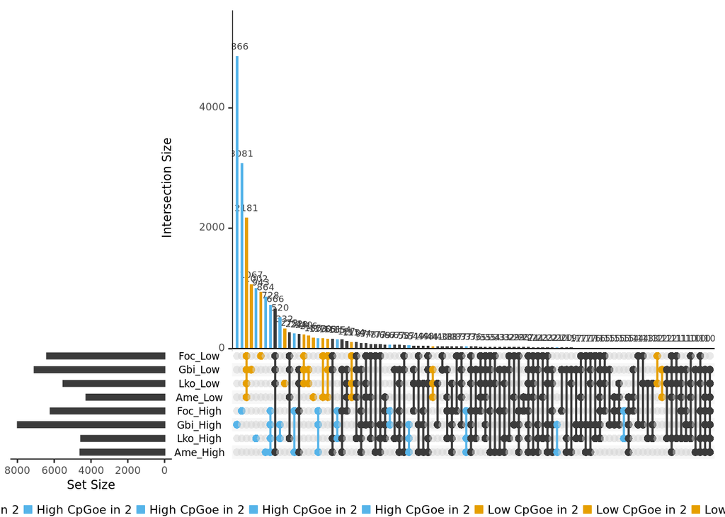

```r
library(UpSetR)

#write.csv(AmeGbiLko_CpGeo_OG, file="Data_for_Fig2BandS4.csv")

Data_for_Upset_v2<-list(Gbi_High=AmeGbiLko_CpGeo_OG[AmeGbiLko_CpGeo_OG$CpGoe_level=="High" & AmeGbiLko_CpGeo_OG$Abb=="Gbi", "OG"],
                     Lko_High=AmeGbiLko_CpGeo_OG[AmeGbiLko_CpGeo_OG$CpGoe_level=="High" & AmeGbiLko_CpGeo_OG$Abb=="Lko", "OG"],
                     Ame_High=AmeGbiLko_CpGeo_OG[AmeGbiLko_CpGeo_OG$CpGoe_level=="High" & AmeGbiLko_CpGeo_OG$Abb=="Ame", "OG"],
                     Foc_High=AmeGbiLko_CpGeo_OG[AmeGbiLko_CpGeo_OG$CpGoe_level=="High" & AmeGbiLko_CpGeo_OG$Abb=="Foc", "OG"],
                     Gbi_Low=AmeGbiLko_CpGeo_OG[AmeGbiLko_CpGeo_OG$CpGoe_level=="Low" & AmeGbiLko_CpGeo_OG$Abb=="Gbi", "OG"],
                     Lko_Low=AmeGbiLko_CpGeo_OG[AmeGbiLko_CpGeo_OG$CpGoe_level=="Low" & AmeGbiLko_CpGeo_OG$Abb=="Lko", "OG"],
                     Ame_Low=AmeGbiLko_CpGeo_OG[AmeGbiLko_CpGeo_OG$CpGoe_level=="Low" & AmeGbiLko_CpGeo_OG$Abb=="Ame", "OG"],
                     Foc_Low=AmeGbiLko_CpGeo_OG[AmeGbiLko_CpGeo_OG$CpGoe_level=="Low" & AmeGbiLko_CpGeo_OG$Abb=="Foc", "OG"])

Data_for_Upset_list_v2<-fromList(Data_for_Upset_v2)

Upset_raw_v3<-upset(Data_for_Upset_list_v2,   order.by = "freq", nintersects = 100,cutoff=100,
      sets = c("Ame_High","Lko_High", "Gbi_High","Foc_High","Ame_Low", "Lko_Low","Gbi_Low","Foc_Low"  ),keep.order = TRUE,
        queries = list(list(query = intersects, params = list("Gbi_Low"),  color = "#E69F00", active = T, query.name = "Low  - No horthology"),
                  list(query = intersects, params = list("Lko_Low"),  color = "#E69F00", active = T, query.name = "Low  - No horthology") ,
                  list(query = intersects, params = list("Ame_Low"),  color = "#E69F00", active = T, query.name = "Low  - No horthology"),
                  list(query = intersects, params = list("Foc_Low"),  color = "#E69F00", active = T, query.name = "Low  - No horthology"),
                  list(query = intersects, params = list("Gbi_High"),  color = "#56B4E9", active = T, query.name = "High - No horthology"),
                  list(query = intersects, params = list("Lko_High"),  color = "#56B4E9", active = T, query.name = "High - No horthology") ,
                  list(query = intersects, params = list("Ame_High"),  color = "#56B4E9", active = T, query.name = "High - No horthology"),
                  list(query = intersects, params = list("Foc_High"),  color = "#56B4E9", active = T, query.name = "High - No horthology"),
                  list(query = intersects, params = list("Gbi_High", "Lko_High"), color = "#56B4E9", active = T, query.name = "High CpGoe in 2"),
                  list(query = intersects, params = list("Gbi_High", "Foc_High"), color = "#56B4E9", active = T, query.name = "High CpGoe in 2"),

                  list(query = intersects, params = list("Foc_High", "Ame_High"), color = "#56B4E9", active = T, query.name = "High CpGoe in 2"),
                  list(query = intersects, params = list("Foc_High", "Gbi_High"), color = "#56B4E9", active = T, query.name = "High CpGoe in 2"),
                  list(query = intersects, params = list("Ame_High", "Gbi_High"), color = "#56B4E9", active = T, query.name = "High CpGoe in 2"),
                  list(query = intersects, params = list("Foc_High", "Lko_High"), color = "#56B4E9", active = T, query.name = "High CpGoe in 2"),

                  list(query = intersects, params = list("Foc_Low",  "Lko_Low"),  color = "#E69F00", active = T, query.name = "Low CpGoe in 2"),
                  list(query = intersects, params = list("Foc_Low",  "Lko_Low"),  color = "#E69F00", active = T, query.name = "Low CpGoe in 2"),

                  list(query = intersects, params = list("Gbi_Low",  "Lko_Low"),  color = "#E69F00", active = T, query.name = "Low CpGoe in 2"),
                  list(query = intersects, params = list("Foc_Low",  "Ame_Low"),  color = "#E69F00", active = T, query.name = "Low CpGoe in 2"),
                  list(query = intersects, params = list("Ame_Low",  "Gbi_Low"),  color = "#E69F00", active = T, query.name = "Low CpGoe in 2"),

                  list(query = intersects, params = list("Gbi_Low",  "Lko_Low",  "Ame_Low"),  color = "#E69F00", active = T, query.name = "Low CpGoe in  3"),
                  list(query = intersects, params = list("Foc_Low",  "Gbi_Low",  "Ame_Low"),  color = "#E69F00", active = T, query.name = "Low CpGoe in  3"),
                  list(query = intersects, params = list("Foc_Low",  "Lko_Low",  "Ame_Low"),  color = "#E69F00", active = T, query.name = "Low CpGoe in  3"),

                   list(query = intersects, params = list("Gbi_Low",  "Lko_Low",  "Foc_Low"),  color = "#E69F00", active = T, query.name = "Low CpGoe in  3"),
                  list(query = intersects, params = list("Gbi_High", "Lko_High", "Ame_High"), color = "#56B4E9", active = T, query.name = "High CpGoe in  3"),
                  list(query = intersects, params = list("Gbi_High", "Foc_High", "Ame_High"), color = "#56B4E9", active = T, query.name = "High CpGoe in  3"),
                  list(query = intersects, params = list("Gbi_High", "Foc_High", "Lko_High"), color = "#56B4E9", active = T, query.name = "High CpGoe in  3"),
                  list(query = intersects, params = list("Foc_High", "Ame_High", "Lko_High"), color = "#56B4E9", active = T, query.name = "High CpGoe in  3"),

                  list(query = intersects, params = list("Gbi_Low",  "Lko_Low",  "Ame_Low","Foc_Low"),  color = "#E69F00", active = T, query.name = "Low CpGoe in all 4"),
                  list(query = intersects, params = list("Gbi_High", "Lko_High", "Ame_High","Foc_High"), color = "#56B4E9", active = T, query.name = "High CpGoe in all 4")
                 # list(query = intersects, params = list("Gbi_High", "Lko_High", "Ame_High","Foc_High","Gbi_Low",  "Lko_Low",  "Ame_Low","Foc_Low"), color = "red", active = T, query.name = "IN ALL")
                 ),
       query.legend = "bottom")
Upset_raw_v3
```

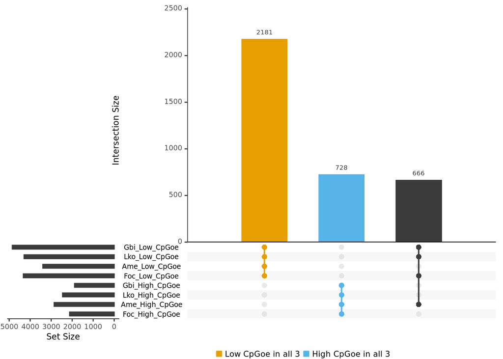

```r
Data_for_Upset_list_v3 <- Data_for_Upset_list_v2
colnames(Data_for_Upset_list_v3) <- paste0(colnames(Data_for_Upset_list_v2),
    "_CpGoe")


Data_for_Upset_list_v4 <- Data_for_Upset_list_v3 %>% filter(rowSums(.) >
    3)


Upset_SubSetstoshow_v2 <- upset(Data_for_Upset_list_v4, nsets = 8,
    order.by = "freq", nintersects = 3, cutoff = 10, sets = c("Foc_High_CpGoe",
        "Ame_High_CpGoe", "Lko_High_CpGoe", "Gbi_High_CpGoe",
        "Foc_Low_CpGoe", "Ame_Low_CpGoe", "Lko_Low_CpGoe", "Gbi_Low_CpGoe"),
    keep.order = TRUE, queries = list(list(query = intersects,
        params = list("Gbi_Low_CpGoe", "Lko_Low_CpGoe", "Ame_Low_CpGoe",
            "Foc_Low_CpGoe"), color = "#E69F00", active = T,
        query.name = "Low CpGoe in all 3"), list(query = intersects,
        params = list("Gbi_High_CpGoe", "Lko_High_CpGoe", "Ame_High_CpGoe",
            "Foc_High_CpGoe"), color = "#56B4E9", active = T,
        query.name = "High CpGoe in all 3")), query.legend = "bottom")


Upset_SubSetstoshow_v2
```

## CpGoe Functional Analysis

- Gene orthology Enrichment Analysis with TopGO.

```r
library("topGO")

## Gbi
conGbi <- dbConnect(RSQLite::SQLite(), "GBI_V3_Annotations.v2.db")
Gbi_Gene_GO <- dbFetch(dbSendQuery(conGbi, "SELECT GeneID,GOterms FROM genes"))
dbDisconnect(conGbi)

dim(Gbi_Gene_GO)
write.table(Gbi_Gene_GO, "Gbi_Gene_GO.csv", row.names = FALSE,
    sep = "\t", quote = FALSE)
geneID2GO_gbi <- readMappings("Gbi_Gene_GO.csv")
head(geneID2GO_gbi)

## Lko
conLko <- dbConnect(RSQLite::SQLite(), "Lko_Annotations.v2.db")
Lko_Gene_GO <- dbFetch(dbSendQuery(conLko, "SELECT GeneID,GOterms FROM genes"))
dbDisconnect(conLko)

dim(Lko_Gene_GO)
write.table(Lko_Gene_GO, "Lko_Gene_GO.csv", row.names = FALSE,
    sep = "\t", quote = FALSE)
geneID2GO_lko <- readMappings("Lko_Gene_GO.csv")
head(geneID2GO_lko)

## Ame For Ame, I ran Iprscan to longest prot per geneql
head(Ame_CpG)
geneID2GO_Ame <- readMappings("Ame_Gene_GO_dict.txt")
head(geneID2GO_Ame)

## Foc ./interproscan-5.34-73.0/interproscan.sh -appl pfam -dp
## -f TSV -goterms -iprlookup -pa -t p -i
## Frankliniella_occidentalis_longest_isoform_nodots.fa -o
## Foc_longest_isoform.iprscan25/09/2020 14:46:29:735 Welcome
## to InterProScan-5.34-73.0 python
## Interproscan_to_Gene_GOterm_Foc.py
geneID2GO_Foc <- readMappings("Foc_Gene_GO_dict.txt")
```

### *Gryllus bimaculatus* CpGoe GO-ernichment

I select genes belonging to the low CpGoe peak (methylated genes). And eprform a GOI-enrichment vs all genes.

#### Gbi Low CpGoe

```r
## Low CpG
dim(Gbi_CpG)#68 less than the 17871, because NA & 0>0CpGoe<0 removed
```

```
## [1] 17803    10
```

```r
GBi_LowCPG<-Gbi_CpG[Gbi_CpG$CpGoe_level=="Low", "Gene" ]


## selected genes/universe
geneListGbiLow=factor(as.integer(Gbi_CpG$Gene %in%  GBi_LowCPG))  ## being or not in the selected ones as Factor
names(geneListGbiLow)= Gbi_CpG$Gene

Gbi_Low_GOdataBP <- new("topGOdata",
                    description = "Gbi Low CpGoe", ontology = "BP",
                    allGenes =geneListGbiLow,
                    ##geneSel = Gbi_CpG$Gene,
                    nodeSize = 10,
                    annot = annFUN.gene2GO,
                    gene2GO =geneID2GO_gbi)

Gbi_Low_GOdataBP
```

```
##
## ------------------------- topGOdata object -------------------------
##
##  Description:
##    -  Gbi Low CpGoe
##
##  Ontology:
##    -  BP
##
##  17803 available genes (all genes from the array):
##    - symbol:  GBI_21039 GBI_21037 GBI_21038 GBI_05592 GBI_05594  ...
##    - 7797  significant genes.
##
##  3552 feasible genes (genes that can be used in the analysis):
##    - symbol:  GBI_05594 GBI_05590 GBI_05597 GBI_05595 GBI_05599  ...
##    - 1987  significant genes.
##
##  GO graph (nodes with at least  10  genes):
##    - a graph with directed edges
##    - number of nodes = 403
##    - number of edges = 745
##
## ------------------------- topGOdata object -------------------------
```

```r
Gbi_Low_weight01_fisher_BP=runTest(Gbi_Low_GOdataBP, algorithm='weight01', statistic='fisher')
#Gbi_Low_weight01_fisher_BP

allGO=usedGO(Gbi_Low_GOdataBP)

res_Gbi_Low_weight0_fisher_BP=GenTable(Gbi_Low_GOdataBP, weightFisher=Gbi_Low_weight01_fisher_BP, orderBy='weightFisher', topNodes=length(allGO), numChar=1000)
res_Gbi_Low_weight0_fisher_BP$pvalue<-topGO::score(Gbi_Low_weight01_fisher_BP)[res_Gbi_Low_weight0_fisher_BP$GO.ID]

#res_Gbi_Low_weight0_fisher_BP$weightFisher<-as.numeric(res_Gbi_Low_weight0_fisher_BP$weightFisher)
#head(res_Gbi_Low_weight0_fisher_BP)

#write.csv(res_Gbi_Low_weight0_fisher_BP, "res_Gbi_Low_weight0_fisher_BP")
```

#### Gbi High CpGoe

```r
# High CpG
GBi_HighCPG<-Gbi_CpG[Gbi_CpG$CpGoe_level=="High", "Gene" ]


## selected genes/universe
geneListGbiHigh=factor(as.integer(Gbi_CpG$Gene %in%   GBi_HighCPG))  ## being or not in the s;leected ones as Factor
names(geneListGbiHigh)= Gbi_CpG$Gene




Gbi_High_GOdataBP <- new("topGOdata",
                    description = "Gbi High CpGoe", ontology = "BP",
                    allGenes =geneListGbiHigh,
                   # #geneSel = Gbi_CpG$Gene,
                    nodeSize = 10,
                    annot = annFUN.gene2GO,
                    gene2GO =geneID2GO_gbi)

Gbi_High_GOdataBP
```

```
##
## ------------------------- topGOdata object -------------------------
##
##  Description:
##    -  Gbi High CpGoe
##
##  Ontology:
##    -  BP
##
##  17803 available genes (all genes from the array):
##    - symbol:  GBI_21039 GBI_21037 GBI_21038 GBI_05592 GBI_05594  ...
##    - 10006  significant genes.
##
##  3552 feasible genes (genes that can be used in the analysis):
##    - symbol:  GBI_05594 GBI_05590 GBI_05597 GBI_05595 GBI_05599  ...
##    - 1565  significant genes.
##
##  GO graph (nodes with at least  10  genes):
##    - a graph with directed edges
##    - number of nodes = 403
##    - number of edges = 745
##
## ------------------------- topGOdata object -------------------------
```

```r
Gbi_High_weight01_fisher_BP=runTest(Gbi_High_GOdataBP, algorithm='weight01', statistic='fisher')
Gbi_High_weight01_fisher_BP
```

```
##
## Description: Gbi High CpGoe
## Ontology: BP
## 'weight01' algorithm with the 'fisher' test
## 403 GO terms scored: 14 terms with p < 0.01
## Annotation data:
##     Annotated genes: 3552
##     Significant genes: 1565
##     Min. no. of genes annotated to a GO: 10
##     Nontrivial nodes: 390
```

```r
allGO=usedGO(Gbi_High_GOdataBP)


res_Gbi_High_weight0_fisher_BP<-GenTable(Gbi_High_GOdataBP, weightFisher=Gbi_High_weight01_fisher_BP, orderBy='weightFisher', topNodes=length(allGO), numChar=1000)
res_Gbi_High_weight0_fisher_BP$pvalue<-topGO::score(Gbi_High_weight01_fisher_BP)[res_Gbi_High_weight0_fisher_BP$GO.ID]
```

### *Laupala kohalensis* CpGoe GO-ernichment

#### Lko Low CpGoe

```r
## Lko Low CpG
Lko_LowCPG<-Lko_CpG[Lko_CpG$CpGoe_level=="Low", "Gene" ]
length(Lko_LowCPG)
```

```
## [1] 6127
```

```r
table(Lko_CpG$CpGoe_level)
```

```
##
## High  Low
## 6618 6127
```

```r
## selected genes/universe
geneListLkoLow=factor(as.integer(Lko_CpG$Gene %in%  Lko_LowCPG))  ## being or not in the s;leected ones as Factor
names(geneListLkoLow)= Lko_CpG$Gene


Lko_Low_GOdataBP <- new("topGOdata",
                    description = "Lko Low CpGoe", ontology = "BP",
                    allGenes =geneListLkoLow,
                    #geneSel = Lko_CpG$Gene,
                    nodeSize = 10,
                    annot = annFUN.gene2GO,
                    gene2GO =geneID2GO_lko)

Lko_Low_GOdataBP
```

```
##
## ------------------------- topGOdata object -------------------------
##
##  Description:
##    -  Lko Low CpGoe
##
##  Ontology:
##    -  BP
##
##  12745 available genes (all genes from the array):
##    - symbol:  Lko_35551 Lko_35552 Lko_31320 Lko_31321 Lko_31325  ...
##    - 6127  significant genes.
##
##  3470 feasible genes (genes that can be used in the analysis):
##    - symbol:  Lko_07571 Lko_07572 Lko_33545 Lko_28272 Lko_23652  ...
##    - 1708  significant genes.
##
##  GO graph (nodes with at least  10  genes):
##    - a graph with directed edges
##    - number of nodes = 388
##    - number of edges = 710
##
## ------------------------- topGOdata object -------------------------
```

```r
Lko_Low_weight01_fisher_BP=runTest(Lko_Low_GOdataBP, algorithm='weight01', statistic='fisher')

allGO=usedGO(Lko_Low_GOdataBP)

res_Lko_Low_weight0_fisher_BP=GenTable(Lko_Low_GOdataBP, weightFisher=Lko_Low_weight01_fisher_BP, orderBy='weightFisher', topNodes=length(allGO), numChar=1000)
res_Lko_Low_weight0_fisher_BP$pvalue<-topGO::score(Lko_Low_weight01_fisher_BP)[res_Lko_Low_weight0_fisher_BP$GO.ID]
```

#### Lko High CpGoe

```r
# High CpG
Lko_HighCPG<-Lko_CpG[Lko_CpG$CpGoe_level=="High", "Gene" ]


## selected genes/universe
geneListLkoHigh=factor(as.integer(Lko_CpG$Gene %in%   Lko_HighCPG))  ## being or not in the s;leected ones as Factor
names(geneListLkoHigh)= Lko_CpG$Gene



Lko_High_GOdataBP <- new("topGOdata",
                    description = "Lko High CpGoe", ontology = "BP",
                    allGenes =geneListLkoHigh,
                    #geneSel = Lko_CpG$Gene,
                    nodeSize = 10,
                    annot = annFUN.gene2GO,
                    gene2GO =geneID2GO_lko)

Lko_High_GOdataBP
```

```
##
## ------------------------- topGOdata object -------------------------
##
##  Description:
##    -  Lko High CpGoe
##
##  Ontology:
##    -  BP
##
##  12745 available genes (all genes from the array):
##    - symbol:  Lko_35551 Lko_35552 Lko_31320 Lko_31321 Lko_31325  ...
##    - 6618  significant genes.
##
##  3470 feasible genes (genes that can be used in the analysis):
##    - symbol:  Lko_07571 Lko_07572 Lko_33545 Lko_28272 Lko_23652  ...
##    - 1762  significant genes.
##
##  GO graph (nodes with at least  10  genes):
##    - a graph with directed edges
##    - number of nodes = 388
##    - number of edges = 710
##
## ------------------------- topGOdata object -------------------------
```

```r
Lko_High_weight01_fisher_BP=runTest(Lko_High_GOdataBP, algorithm='weight01', statistic='fisher')
Lko_High_weight01_fisher_BP
```

```
##
## Description: Lko High CpGoe
## Ontology: BP
## 'weight01' algorithm with the 'fisher' test
## 388 GO terms scored: 11 terms with p < 0.01
## Annotation data:
##     Annotated genes: 3470
##     Significant genes: 1762
##     Min. no. of genes annotated to a GO: 10
##     Nontrivial nodes: 385
```

```r
allGO=usedGO(Lko_High_GOdataBP)


res_Lko_High_weight0_fisher_BP=GenTable(Lko_High_GOdataBP, weightFisher=Lko_High_weight01_fisher_BP, orderBy='weightFisher', topNodes=length(allGO), numChar=1000)
res_Lko_High_weight0_fisher_BP$pvalue<-topGO::score(Lko_High_weight01_fisher_BP)[res_Lko_High_weight0_fisher_BP$GO.ID]
```

### *Apis mellifera* CpGoe GO-ernichment

#### Ame Low CpGoe

```r
Ame_cds_gene_dic<-read.delim("Ame_Gene_CDS_dict.txt", header = FALSE, sep=" ")
#head(Ame_cds_gene_dic)
colnames(Ame_cds_gene_dic)<-c("LOC","XM")
Ame_CpG_LOC<-merge(Ame_CpG,Ame_cds_gene_dic, by.x="Gene", by.y="XM" )


## Ame Low CpG
Ame_LowCPG<-Ame_CpG_LOC[Ame_CpG_LOC$CpGoe_level=="Low", "LOC" ]


## selected genes/universe
geneListAmeLow=factor(as.integer(Ame_CpG_LOC$LOC %in%  Ame_LowCPG))  ## being or not in the s;leected ones as Factor
names(geneListAmeLow)= Ame_CpG_LOC$LOC


Ame_Low_GOdataBP <- new("topGOdata",
                    description = "Ame Low CpGoe", ontology = "BP",
                    allGenes =geneListAmeLow,
                    #geneSel = Ame_CpG$Gene,
                    nodeSize = 10,
                    annot = annFUN.gene2GO,
                    gene2GO =geneID2GO_Ame)

Ame_Low_GOdataBP
```

```
##
## ------------------------- topGOdata object -------------------------
##
##  Description:
##    -  Ame Low CpGoe
##
##  Ontology:
##    -  BP
##
##  9934 available genes (all genes from the array):
##    - symbol:  ATP6 ATP8 COX1 COX2 COX3  ...
##    - 4401  significant genes.
##
##  3020 feasible genes (genes that can be used in the analysis):
##    - symbol:  ATP6 COX1 COX2 ND1 ND3  ...
##    - 1319  significant genes.
##
##  GO graph (nodes with at least  10  genes):
##    - a graph with directed edges
##    - number of nodes = 387
##    - number of edges = 697
##
## ------------------------- topGOdata object -------------------------
```

```r
Ame_Low_weight01_fisher_BP=runTest(Ame_Low_GOdataBP, algorithm='weight01', statistic='fisher')

allGO=usedGO(Ame_Low_GOdataBP)

res_Ame_Low_weight0_fisher_BP=GenTable(Ame_Low_GOdataBP, weightFisher=Ame_Low_weight01_fisher_BP, orderBy='weightFisher', topNodes=length(allGO), numChar=1000)

res_Ame_Low_weight0_fisher_BP$pvalue<-topGO::score(Ame_Low_weight01_fisher_BP)[res_Ame_Low_weight0_fisher_BP$GO.ID]
```

#### Ame High CpGoe

```r
## Ame High CpG
Ame_HighCPG<-Ame_CpG_LOC[Ame_CpG_LOC$CpGoe_level=="High", "LOC" ]


## selected genes/universe
geneListAmeHigh=factor(as.integer(Ame_CpG_LOC$LOC %in%  Ame_HighCPG))  ## being or not in the s;leected ones as Factor
names(geneListAmeHigh)= Ame_CpG_LOC$LOC


Ame_High_GOdataBP <- new("topGOdata",
                    description = "Ame High CpGoe", ontology = "BP",
                    allGenes =geneListAmeHigh,
                    #geneSel = Ame_CpG$Gene,
                    nodeSize = 10,
                    annot = annFUN.gene2GO,
                    gene2GO =geneID2GO_Ame)

Ame_High_GOdataBP
```

```
##
## ------------------------- topGOdata object -------------------------
##
##  Description:
##    -  Ame High CpGoe
##
##  Ontology:
##    -  BP
##
##  9934 available genes (all genes from the array):
##    - symbol:  ATP6 ATP8 COX1 COX2 COX3  ...
##    - 5533  significant genes.
##
##  3020 feasible genes (genes that can be used in the analysis):
##    - symbol:  ATP6 COX1 COX2 ND1 ND3  ...
##    - 1701  significant genes.
##
##  GO graph (nodes with at least  10  genes):
##    - a graph with directed edges
##    - number of nodes = 387
##    - number of edges = 697
##
## ------------------------- topGOdata object -------------------------
```

```r
Ame_High_weight01_fisher_BP=runTest(Ame_High_GOdataBP, algorithm='weight01', statistic='fisher')

allGO=usedGO(Ame_High_GOdataBP)

res_Ame_High_weight0_fisher_BP=GenTable(Ame_High_GOdataBP, weightFisher=Ame_High_weight01_fisher_BP, orderBy='weightFisher', topNodes=length(allGO), numChar=1000)
res_Ame_High_weight0_fisher_BP$pvalue<-topGO::score(Ame_High_weight01_fisher_BP)[res_Ame_High_weight0_fisher_BP$GO.ID]
```

### *Frankliniella occidentalis* CpGoe GO-ernichment

#### Foc Low CpGoe

```r
geneID2GO_Foc <- readMappings("Foc_Gene_GO_dict.txt")
head(geneID2GO_Foc)
```

```
## $LOC113214399
## [1] "GO:0006486" "GO:0008378" "GO:0016020"
##
## $LOC113214394
## [1] "GO:0003924"
##
## $LOC113214395
## [1] "GO:0005622" "GO:0008270"
##
## $LOC113214396
## [1] "GO:0004143" "GO:0005509" "GO:0007205" "GO:0016301" "GO:0035556"
##
## $LOC113214393
## [1] "GO:0016020"
##
## $LOC113208211
## [1] "GO:0016192"
```

```r
length(geneID2GO_Foc)
```

```
## [1] 7040
```

```r
## Foc Low CpG
Foc_LowCPG<-Foc_CpG[Foc_CpG$CpGoe_level=="Low", "Gene" ]



## selected genes/universe
geneListFocLow=factor(as.integer(Foc_CpG$Gene %in%  Foc_LowCPG))  ## being or not in the s;leected ones as Factor
names(geneListFocLow)= Foc_CpG$Gene


Foc_Low_GOdataBP <- new("topGOdata",
                    description = "Foc Low CpGoe", ontology = "BP",
                    allGenes =geneListFocLow,
                    #geneSel = Foc_CpG$Gene,
                    nodeSize = 10,
                    annot = annFUN.gene2GO,
                    gene2GO =geneID2GO_Foc)

Foc_Low_GOdataBP
```

```
##
## ------------------------- topGOdata object -------------------------
##
##  Description:
##    -  Foc Low CpGoe
##
##  Ontology:
##    -  BP
##
##  15678 available genes (all genes from the array):
##    - symbol:  LOC113201678 LOC113201679 LOC113201680 LOC113201681 LOC113201682  ...
##    - 7244  significant genes.
##
##  3862 feasible genes (genes that can be used in the analysis):
##    - symbol:  LOC113201678 LOC113201681 LOC113201685 LOC113201688 LOC113201690  ...
##    - 1877  significant genes.
##
##  GO graph (nodes with at least  10  genes):
##    - a graph with directed edges
##    - number of nodes = 420
##    - number of edges = 777
##
## ------------------------- topGOdata object -------------------------
```

```r
Foc_Low_weight01_fisher_BP=runTest(Foc_Low_GOdataBP, algorithm='weight01', statistic='fisher')
#Foc_Low_weight01_fisher_BP

allGO=usedGO(Foc_Low_GOdataBP)

res_Foc_Low_weight0_fisher_BP=GenTable(Foc_Low_GOdataBP, weightFisher=Foc_Low_weight01_fisher_BP, orderBy='weightFisher', topNodes=length(allGO), numChar=1000)
res_Foc_Low_weight0_fisher_BP$pvalue<-topGO::score(Foc_Low_weight01_fisher_BP)[res_Foc_Low_weight0_fisher_BP$GO.ID]
```

#### Foc High CpGoe

```r
## Foc High CpG
Foc_HighCPG<-Foc_CpG[Foc_CpG$CpGoe_level=="High", "Gene" ]


## selected genes/universe
geneListFocHigh=factor(as.integer(Foc_CpG$Gene %in%  Foc_HighCPG))  ## being or not in the s;leected ones as Factor
names(geneListFocHigh)= Foc_CpG$Gene
#head(geneListFocHigh)
#table(geneListFocHigh)



Foc_High_GOdataBP <- new("topGOdata",
                    description = "Foc High CpGoe", ontology = "BP",
                    allGenes =geneListFocHigh,
                    #geneSel = Foc_CpG$Gene,
                    nodeSize = 10,
                    annot = annFUN.gene2GO,
                    gene2GO =geneID2GO_Foc)

Foc_High_GOdataBP
```

```
##
## ------------------------- topGOdata object -------------------------
##
##  Description:
##    -  Foc High CpGoe
##
##  Ontology:
##    -  BP
##
##  15678 available genes (all genes from the array):
##    - symbol:  LOC113201678 LOC113201679 LOC113201680 LOC113201681 LOC113201682  ...
##    - 8434  significant genes.
##
##  3862 feasible genes (genes that can be used in the analysis):
##    - symbol:  LOC113201678 LOC113201681 LOC113201685 LOC113201688 LOC113201690  ...
##    - 1985  significant genes.
##
##  GO graph (nodes with at least  10  genes):
##    - a graph with directed edges
##    - number of nodes = 420
##    - number of edges = 777
##
## ------------------------- topGOdata object -------------------------
```

```r
Foc_High_weight01_fisher_BP=runTest(Foc_High_GOdataBP, algorithm='weight01', statistic='fisher')

allGO=usedGO(Foc_High_GOdataBP)

res_Foc_High_weight0_fisher_BP=GenTable(Foc_High_GOdataBP, weightFisher=Foc_High_weight01_fisher_BP, orderBy='weightFisher', topNodes=length(allGO), numChar=1000)

res_Foc_High_weight0_fisher_BP$pvalue<-topGO::score(Foc_High_weight01_fisher_BP)[res_Foc_High_weight0_fisher_BP$GO.ID]
```

### GO Visualization

```r
All_Goes <- rbind(cbind(res_Gbi_High_weight0_fisher_BP, Class = "Gbi_High"),
    cbind(res_Lko_High_weight0_fisher_BP, Class = "Lko_High"),
    cbind(res_Foc_High_weight0_fisher_BP, Class = "Foc_High"),
    cbind(res_Ame_High_weight0_fisher_BP, Class = "Ame_High"),
    cbind(res_Gbi_Low_weight0_fisher_BP, Class = "Gbi_Low"),
    cbind(res_Lko_Low_weight0_fisher_BP, Class = "Lko_Low"),
    cbind(res_Foc_Low_weight0_fisher_BP, Class = "Foc_Low"),
    cbind(res_Ame_Low_weight0_fisher_BP, Class = "Ame_Low"))
```

### All significant GOS (Fig S3)

```r
# OrderTerms<- All_Goes %>%filter(pvalue<0.01) %>%
# group_by(GO.ID,Term, Class) %>% tally(name='num',sort=TRUE)
# %>% ungroup() %>% group_by(GO.ID,Term)
# %>%tally(name='Ocurrences',sort=TRUE)
OrderTerms <- All_Goes %>% filter(pvalue < 0.05) %>% separate(col = Class,
    "_", into = c("Spp", "HighLow"), remove = F) %>% group_by(GO.ID,
    Term, HighLow, Class) %>% tally(name = "num", sort = TRUE) %>%
    ungroup() %>% group_by(GO.ID, Term, HighLow) %>% tally(name = "Ocurrences",
    sort = TRUE)

Significants <- All_Goes %>% filter(pvalue < 0.05) %>% dplyr::select(GO.ID) %>%
    distinct(GO.ID)

All_Goes_Factors <- All_Goes %>% filter(GO.ID %in% Significants$GO.ID) %>%
    left_join(OrderTerms, by = c(GO.ID = "GO.ID")) %>% mutate(Term_factors = as.factor(Term.x)) %>%
    mutate(Term_factors = fct_reorder2(Term_factors, Ocurrences,
        HighLow, .desc = TRUE)) %>% mutate(significancelevel = ifelse(as.numeric(pvalue) <
    0.001, "<0.001", pvalue)) %>% mutate(significancelevel = ifelse(as.numeric(pvalue) <=
    0.05 & as.numeric(pvalue) > 0.001, "[0.05,0.001)", significancelevel)) %>%
    mutate(significancelevel = ifelse(as.numeric(pvalue) > 0.05,
        ">0.05", significancelevel)) %>% mutate(Class = fct_relevel(Class,
    c("Gbi_Low", "Lko_Low", "Foc_Low", "Ame_Low", "Gbi_High",
        "Lko_High", "Foc_High", "Ame_High"))) %>% mutate(significancelevel = as.factor(significancelevel)) %>%
    mutate(significancelevel = fct_relevel(significancelevel,
        c(">0.05", "[0.05,0.001)", "<0.001")))
```

- Fig S3, too large to plot here

```r
# ggplot(All_Goes_Factors, aes(Term_factors, Class )) +
# geom_point(aes(fill=significancelevel, size =
# Significant/Annotated*100),shape = 21, stroke = 0.1)+
# coord_flip()+ scale_fill_tableau(palette = 'Tableau 10',
# type = c('regular'), direction = 1)+ theme_bw()+
# labs(y='',x='')+ theme(title=element_text(size=10,
# hjust=0.5), axis.title=element_text(size=10), axis.text =
# element_text(size=10), axis.text.x = element_text(angle =
# 45, hjust=1) )
```

### Selected GO terms to show in Fig 3

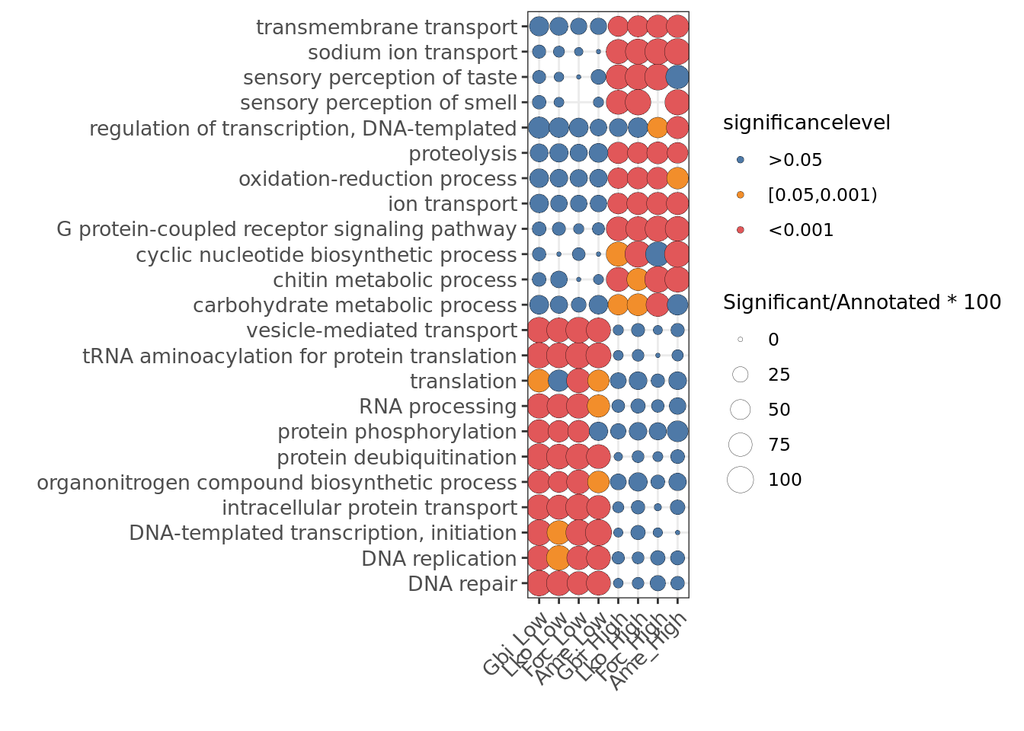

```r
library(ggthemes)

## Selected Goterms to show
TOPSignificants <- All_Goes %>% filter(pvalue < 1e-05) %>% dplyr::select(GO.ID) %>%
    distinct(GO.ID)

Selected_Goes_Factors <- All_Goes_Factors %>% filter(GO.ID %in%
    TOPSignificants$GO.ID)


SELECTED_Point_plot <- ggplot(Selected_Goes_Factors, aes(Term_factors,
    Class)) + geom_point(aes(fill = significancelevel, size = Significant/Annotated *
    100), shape = 21, stroke = 0.1) + coord_flip() + scale_fill_tableau(palette = "Tableau 10",
    type = c("regular"), direction = 1) + theme_bw() + labs(y = "",
    x = "") + theme(title = element_text(size = 10, hjust = 0.5),
    axis.title = element_text(size = 10), axis.text = element_text(size = 10),
    axis.text.x = element_text(angle = 45, hjust = 1))

SELECTED_Point_plot
```

## CpGoe vs dNds (Fig 2D)

- Load dNdS results from the dNds Naysis file

```r
Omega_Gbi_Lko <- read.csv("dNdS_Gbi_Lko.csv", header = T, sep = "\t",
    stringsAsFactors = FALSE)
Omega_Gbi_Lko$OG <- sapply(strsplit(as.character(Omega_Gbi_Lko$key),
    "_"), `[`, 2)
```

```r
Omega_Gbi_Lko_CpG0 <- merge(Omega_Gbi_Lko, AmeGbiLko_CpGeo_OG[AmeGbiLko_CpGeo_OG$Abb ==
    "Gbi", c("OG", "CpGoe", "CpGoe_level")], by.x = "OG", by.y = "OG",
    all.y = FALSE)


Omega_Gbi_Lko_CpG <- merge(Omega_Gbi_Lko_CpG0, AmeGbiLko_CpGeo_OG[AmeGbiLko_CpGeo_OG$Abb ==
    "Lko", c("OG", "CpGoe", "CpGoe_level")], by.x = "OG", by.y = "OG",
    suffixes = c("Gbi", "Lko"), all.y = FALSE)

Omega_Gbi_Lko_CpG$Both_CpGlevels <- paste(Omega_Gbi_Lko_CpG$CpGoe_levelGbi,
    Omega_Gbi_Lko_CpG$CpGoe_levelLko, sep = "_")

prop.table(table(Omega_Gbi_Lko_CpG$Both_CpGlevels)) * 100
```

```
##
## High_High  High_Low  Low_High   Low_Low
## 20.558952  4.471616 12.663755 62.305677
```

```r
## Filter genes omega=none
Omega_Gbi_Lko_CpG <- Omega_Gbi_Lko_CpG[!Omega_Gbi_Lko_CpG$Omega %like%
    "None", ]

Omega_Gbi_Lko_CpG$Both_CpGlevels <- as.factor(Omega_Gbi_Lko_CpG$Both_CpGlevels)

Omega_Gbi_Lko_CpG$Both_CpGlevels <- factor(Omega_Gbi_Lko_CpG$Both_CpGlevels,
    levels = c("Low_Low", "High_High", "High_Low", "Low_High"))
```

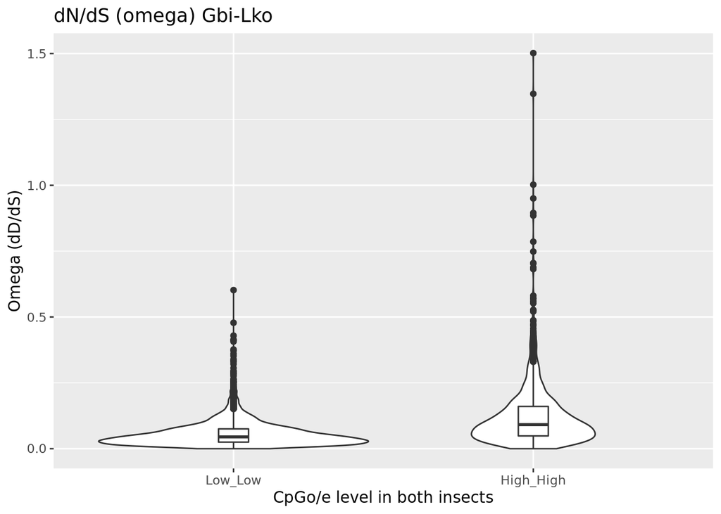

```r
ggplot(subset(Omega_Gbi_Lko_CpG, Both_CpGlevels == "High_High" |
    Both_CpGlevels == "Low_Low"), aes(x = Both_CpGlevels, y = as.numeric(Omega))) +
    geom_violin() + geom_boxplot(width = 0.1) + ggtitle("dN/dS (omega) Gbi-Lko") +
    ylab("Omega (dD/dS)") + xlab("CpGo/e level in both insects")
```

```r
## It applies Wilcoxon-Mann-Whitney test (Mann-Whitney one
## data is not paired)
wilcox.test(subset(Omega_Gbi_Lko_CpG, Both_CpGlevels == "High_High")$Omega,
    subset(Omega_Gbi_Lko_CpG, Both_CpGlevels == "Low_Low")$Omega,
    paired = F)
```

```
##
##  Wilcoxon rank sum test with continuity correction
##
## data:  subset(Omega_Gbi_Lko_CpG, Both_CpGlevels == "High_High")$Omega and subset(Omega_Gbi_Lko_CpG, Both_CpGlevels == "Low_Low")$Omega
## W = 3027728, p-value < 2.2e-16
## alternative hypothesis: true location shift is not equal to 0
```